# Analisis CRISP-DM: "Rain in Australia"

### Vista del R² y Raíz del error cuadrática medio

```python
# for que recorra la lista de modelos y que imprima el MAE, MSE y RMSE, R2 de cada modelo
from sklearn.metrics import mean_absolute_error, mean_squared_error, r2_score
i = 1
for model in models:
    y_pred_reg = model.predict(X_test_reg)
    print(f'{i}° Modelo de Clasificación -> {model}\n')
    print('-'*100)
    print(f'El MSE del modelo es {mean_squared_error(y_test_reg, y_pred_reg):.2f}')
    print(f'El RMSE del modelo es {np.sqrt(mean_squared_error(y_test_reg, y_pred_reg)):.2f}')
    print(f'El R² del modelo es {r2_score(y_test_reg, y_pred_reg):.2f}\n')
    print('-'*100,'\n')
    i += 1
```

```
1° Modelo de Clasificación -> DecisionTreeRegressor()

----------------------------------------------------------------------------------------------------
El MSE del modelo es 0.00
El RMSE del modelo es 0.06
El R² del modelo es -0.38

----------------------------------------------------------------------------------------------------

2° Modelo de Clasificación -> RandomForestRegressor()

----------------------------------------------------------------------------------------------------
El MSE del modelo es 0.00
El RMSE del modelo es 0.05
El R² del modelo es 0.21

----------------------------------------------------------------------------------------------------

3° Modelo de Clasificación -> GradientBoostingRegressor()

----------------------------------------------------------------------------------------------------
El MSE del modelo es 0.00
El RMSE del modelo es 0.05
El R² del modelo es 0.26

----------------------------------------------------------------------------------------------------

4° Modelo de Clasificación -> KNeighborsRegressor()

----------------------------------------------------------------------------------------------------
El MSE del modelo es 0.00
El RMSE del modelo es 0.05
El R² del modelo es 0.18

----------------------------------------------------------------------------------------------------

5° Modelo de Clasificación -> SGDRegressor()

----------------------------------------------------------------------------------------------------
El MSE del modelo es 0.00
El RMSE del modelo es 0.05
El R² del modelo es 0.18

----------------------------------------------------------------------------------------------------
```

### Entrenamiento de Modelos con hiperparámetros

#### GradientBoostingRegressor

##### GradientBoostingRegressor V1

```python
gbV1 = GradientBoostingRegressor( learning_rate=0.1, n_estimators=100, max_depth=3, tol=2, random_state=42)
gbV1.fit(X_train_reg, y_train_reg)
```

```
GradientBoostingRegressor(random_state=42, tol=2)
```

##### GradientBoostingRegressor V2

```python
gbV2 = GradientBoostingRegressor(
    learning_rate=0.1, n_estimators=500, max_depth=3, tol=2, random_state=42)
gbV2.fit(X_train_reg, y_train_reg)
```

```
GradientBoostingRegressor(n_estimators=500, random_state=42, tol=2)
```

##### GradientBoostingRegressor V5

```python
gbV5 = GradientBoostingRegressor( learning_rate=0.4, n_estimators=1, max_depth=3000, tol=1e-2, random_state=42)
gbV5.fit(X_train_reg, y_train_reg)
```

```
GradientBoostingRegressor(learning_rate=0.4, max_depth=3000, n_estimators=1,
                          random_state=42, tol=0.01)
```

```python
models = [gbV1, gbV2, gbV5]
i = 1
for model in models:
    y_pred_reg = model.predict(X_test_reg)
    print(f'{i}° Modelo de Clasificación -> {model}\n')
    print('-'*100)
    print(
        f'El MSE del modelo es {mean_squared_error(y_test_reg, y_pred_reg):.2f}')
    print(f'El RMSE del modelo es {np.sqrt(mean_squared_error(y_test_reg, y_pred_reg)):.2f}')
    print(f'El R² del modelo es {r2_score(y_test_reg, y_pred_reg):.2f}\n')
    print('-'*100, '\n')
    i += 1
```

```
1° Modelo de Clasificación -> GradientBoostingRegressor(random_state=42, tol=2)

----------------------------------------------------------------------------------------------------
El MSE del modelo es 0.00
El RMSE del modelo es 0.05
El R² del modelo es 0.26

----------------------------------------------------------------------------------------------------

2° Modelo de Clasificación -> GradientBoostingRegressor(n_estimators=500, random_state=42, tol=2)

----------------------------------------------------------------------------------------------------
El MSE del modelo es 0.00
El RMSE del modelo es 0.05
El R² del modelo es 0.26

----------------------------------------------------------------------------------------------------

3° Modelo de Clasificación -> GradientBoostingRegressor(learning_rate=0.4, max_depth=3000, n_estimators=1,
                          random_state=42, tol=0.01)

----------------------------------------------------------------------------------------------------
El MSE del modelo es 0.00
El RMSE del modelo es 0.05
El R² del modelo es 0.10

----------------------------------------------------------------------------------------------------
```

#### RandomForestRegressor

##### RandomForestRegressor V1

```python
rfRV1 = RandomForestRegressor(min_samples_split=5, min_samples_leaf=5, random_state=42,
                           bootstrap=True, max_samples=0.8, n_estimators=3, max_depth=40)

rfRV1.fit(X_train_reg, y_train_reg)
```

```
RandomForestRegressor(max_depth=40, max_samples=0.8, min_samples_leaf=5,
                      min_samples_split=5, n_estimators=3, random_state=42)
```

##### RandomForestRegressor V2

```python
rfRV2 = RandomForestRegressor(min_samples_split=50, min_samples_leaf=50, random_state=42,
                           bootstrap=True, max_samples=0.8, n_estimators=12, max_depth=40)

rfRV2.fit(X_train_reg, y_train_reg)
```

```
RandomForestRegressor(max_depth=40, max_samples=0.8, min_samples_leaf=50,
                      min_samples_split=50, n_estimators=12, random_state=42)
```

#### KNeighborsRegressor

```python
knnRV1 = KNeighborsRegressor(
    n_neighbors=2000, weights='distance', algorithm='auto', leaf_size=40, p=2)

knnRV1.fit(X_train_reg, y_train_reg)
```

```
KNeighborsRegressor(leaf_size=40, n_neighbors=2000, weights='distance')
```

#### SGDRegressor

##### SGDRegressor V1

```python
sgdRV1 = SGDRegressor(max_iter=1200000, tol=1e-4, penalty=None,
                      eta0=0.8, n_iter_no_change=1000, random_state=42)

sgdRV1.fit(X_train_reg, y_train_reg)
```

```
SGDRegressor(eta0=0.8, max_iter=1200000, n_iter_no_change=1000, penalty=None,
             random_state=42, tol=0.0001)
```

```python
# generar una lista con todos los modelos de regresion
models = [ rfRV1, rfRV2, knnRV1, sgdRV1]

i=1
# for que recorra la lista de modelos y que imprima el RMSE, R2 de cada modelo
for model in models:
    y_pred_reg = model.predict(X_test_reg)
    print(f'{i}° Modelo de Clasificación -> {model}\n')
    print('-'*100)
    print(
        f'El MSE del modelo es {mean_squared_error(y_test_reg, y_pred_reg):.2f}')
    print(
        f'El RMSE del modelo es {np.sqrt(mean_squared_error(y_test_reg, y_pred_reg)):.2f}')
    print(f'El R² del modelo es {r2_score(y_test_reg, y_pred_reg):.2f}\n')
    print('-'*100,'\n')
    i = i + 1
```

```
1° Modelo de Clasificación -> RandomForestRegressor(max_depth=40, max_samples=0.8, min_samples_leaf=5,
                      min_samples_split=5, n_estimators=3, random_state=42)

----------------------------------------------------------------------------------------------------
El MSE del modelo es 0.00
El RMSE del modelo es 0.05
El R² del modelo es 0.20

----------------------------------------------------------------------------------------------------

2° Modelo de Clasificación -> RandomForestRegressor(max_depth=40, max_samples=0.8, min_samples_leaf=50,
                      min_samples_split=50, n_estimators=12, random_state=42)

----------------------------------------------------------------------------------------------------
El MSE del modelo es 0.00
El RMSE del modelo es 0.04
El R² del modelo es 0.27

----------------------------------------------------------------------------------------------------

3° Modelo de Clasificación -> KNeighborsRegressor(leaf_size=40, n_neighbors=2000, weights='distance')

----------------------------------------------------------------------------------------------------
El MSE del modelo es 0.00
El RMSE del modelo es 0.05
El R² del modelo es 0.19

----------------------------------------------------------------------------------------------------

4° Modelo de Clasificación -> SGDRegressor(eta0=0.8, max_iter=1200000, n_iter_no_change=1000, penalty=None,
             random_state=42, tol=0.0001)

----------------------------------------------------------------------------------------------------
El MSE del modelo es 0.00
El RMSE del modelo es 0.05
El R² del modelo es 0.19

----------------------------------------------------------------------------------------------------
```

#### Decisión

Todos los algoritmos entrenados dan valores que no representan confianza, asi que no se decidirá usar los de regresion para predecir, en su lugar usaremos el de clasificacion, ya que ambos target apuntan a lo mismo

### 4.2 Clasificación

#### Target seleccionado : RainTomorrow_Yes

- Mayores Correlaciones

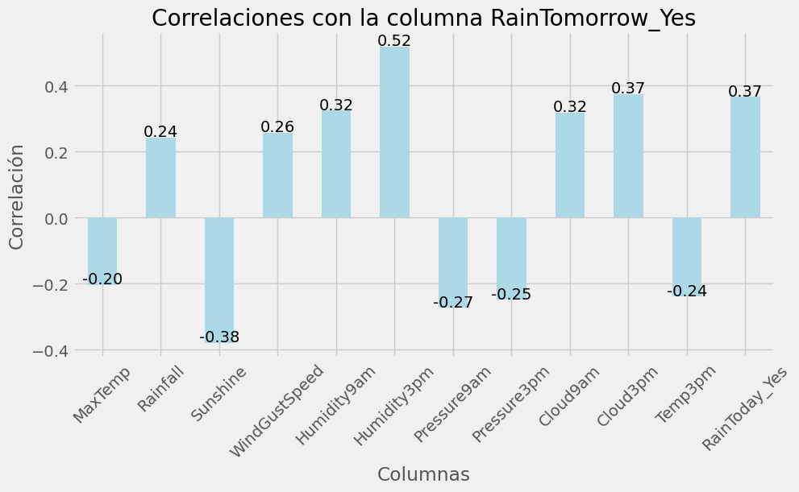

```python
# sacar las correlaciones mayores a 0.2 y menores a -0.2 de las columnas RainTomorrow_Yes y risk_mm
correlation = df.corr()
correlation_target_tomorrow = correlation['RainTomorrow_Yes']
correlation_target_tomorrow = correlation_target_tomorrow[(correlation_target_tomorrow > 0.12) | (correlation_target_tomorrow < -0.15)]
correlation_target_tomorrow = correlation_target_tomorrow.drop(['RainTomorrow_Yes', 'RISK_MM'])
correlation_target_tomorrow

# graficar las correlaciones mayores a 0.2 y menores a -0.2 de las columnas RainTomorrow_Yes y risk_mm
plt.figure(figsize=(10, 5))
ax = correlation_target_tomorrow.plot(kind='bar', color='lightblue')
for p in ax.patches:
    ax.annotate(f"{p.get_height():.2f}", (p.get_x() + p.get_width() / 2., p.get_height()),
                ha='center', va='center', xytext=(0, 5), textcoords='offset points', color='black')
plt.title('Correlaciones con la columna RainTomorrow_Yes', color='black')
plt.xlabel('Columnas')
plt.ylabel('Correlación')
plt.xticks(rotation=45)
plt.show()
```

- Importe de librerías

```python
# importar todos los modelos de clasificacion de sklearn
from sklearn.tree import DecisionTreeClassifier
from sklearn.ensemble import RandomForestClassifier
from sklearn.ensemble import GradientBoostingClassifier
from sklearn.neighbors import KNeighborsClassifier
```

### Separamos datos de entrenamiento y testeo

```python
# separar train y test de def_clas con un 80% para train y 20% para test y random_state=42
X_train_clas, X_test_clas, y_train_clas, y_test_clas = train_test_split(
    df[list_correlation_target_tomorrow], df['RainTomorrow_Yes'], test_size=0.2, random_state=42)
```

### Modelos sin hiperparámetros

Realizaremos un entrenamiento previo sin hiperparámetros para tener una vista preliminar del posible mejor modelo, los modelos seleccionados serán:

- DecisionTreeClassifier
- RandomForestClassifier
- GradientBoostingClassifier
- KNeighborsClassifier

```python
dt = DecisionTreeClassifier()
dt.fit(X_train_clas, y_train_clas)
```

```
DecisionTreeClassifier()
```

```python
rf = RandomForestClassifier()
rf.fit(X_train_clas, y_train_clas)
```

```
RandomForestClassifier()
```

```python
gb = GradientBoostingClassifier()
gb.fit(X_train_clas, y_train_clas)
```

```
GradientBoostingClassifier()
```

```python
knn = KNeighborsClassifier()
knn.fit(X_train_clas, y_train_clas)
```

```
KNeighborsClassifier()
```

### Entrenamiento de Modelos con hiperparámetros

#### DecisionTreeClassifier

##### DecisionTreeClassifier V1

```python
dt_1 = DecisionTreeClassifier(max_depth=2, random_state=42, criterion='entropy')
dt_1.fit(X_train_clas, y_train_clas)
```

```
DecisionTreeClassifier(criterion='entropy', max_depth=2, random_state=42)
```

##### DecisionTreeClassifier V2

```python
dt_2 = DecisionTreeClassifier(
    max_depth=2, random_state=42, criterion='gini')
dt_2.fit(X_train_clas, y_train_clas)
```

```
DecisionTreeClassifier(max_depth=2, random_state=42)
```

##### DecisionTreeClassifier V3

```python
dt_3 = DecisionTreeClassifier(
    max_depth=2, random_state=42, criterion='log_loss')
dt_3.fit(X_train_clas, y_train_clas)
```

```
DecisionTreeClassifier(criterion='log_loss', max_depth=2, random_state=42)
```

##### DecisionTreeClassifier V4

```python
dt_4 = DecisionTreeClassifier(
    max_depth=2, random_state=42, criterion='gini', min_samples_leaf=10)
dt_4.fit(X_train_clas, y_train_clas)
```

```
DecisionTreeClassifier(max_depth=2, min_samples_leaf=10, random_state=42)
```

#### RandomForestClassifier

##### RandomForestClassifier V1

```python
rf_1 = RandomForestClassifier(max_depth=2, random_state=42)
rf_1.fit(X_train_clas, y_train_clas)
```

```
RandomForestClassifier(max_depth=2, random_state=42)
```

##### RandomForestClassifier V2

```python
rf_2 = RandomForestClassifier(max_depth=3, random_state=42)
rf_2.fit(X_train_clas, y_train_clas)
```

```
RandomForestClassifier(max_depth=3, random_state=42)
```

##### RandomForestClassifier V3

```python
rf_3 = RandomForestClassifier(max_depth=15, random_state=42)
rf_3.fit(X_train_clas, y_train_clas)
```

```
RandomForestClassifier(max_depth=15, random_state=42)
```

##### RandomForestClassifier V4

```python
rf_4 = RandomForestClassifier(max_depth=3, random_state=42,
                              min_samples_leaf=10, n_estimators=1000)
rf_4.fit(X_train_clas, y_train_clas)
```

```
RandomForestClassifier(max_depth=3, min_samples_leaf=10, n_estimators=1000,
                       random_state=42)
```

#### GradientBoostingClassifier

##### GradientBoostingClassifier V1

```python
gb_1 = GradientBoostingClassifier(max_depth=2, random_state=42)
gb_1.fit(X_train_clas, y_train_clas)
```

```
GradientBoostingClassifier(max_depth=2, random_state=42)
```

##### GradientBoostingClassifier V2

```python
gb_2 = GradientBoostingClassifier(loss='exponential' ,learning_rate=0.1, n_estimators=150, max_depth=3, random_state=42)
gb_2.fit(X_train_clas, y_train_clas)
```

```
GradientBoostingClassifier(loss='exponential', n_estimators=150,
                           random_state=42)
```

##### GradientBoostingClassifier V3

```python
gb_3 = GradientBoostingClassifier(
    learning_rate=0.001, n_estimators=1500, max_depth=3, random_state=42, min_samples_leaf=10)
gb_3.fit(X_train_clas, y_train_clas)
```

```
GradientBoostingClassifier(learning_rate=0.001, min_samples_leaf=10,
                           n_estimators=1500, random_state=42)
```

#### KNeighborsClassifier

##### KNeighborsClassifier V1

```python
knn_1 = KNeighborsClassifier(n_neighbors=2)
knn_1.fit(X_train_clas, y_train_clas)
```

```
KNeighborsClassifier(n_neighbors=2)
```

Se genera una lista con los modelos

```python
models = [  dt, rf, gb, knn,
            dt_1, dt_2, dt_3, dt_4,
            rf_1, rf_2, rf_3, rf_4,
            gb_1, gb_2, gb_3,
            knn_1]
```